# YouBike Demand Forecasting

Ryan Huang

5/20/2019

#Import Data

```r
options(stringsAsFactors = FALSE)
file_path = "time_filtered_data.csv"
data = read.csv(file_path)
```

#EDA ## Freq: Find the 3 most used stations

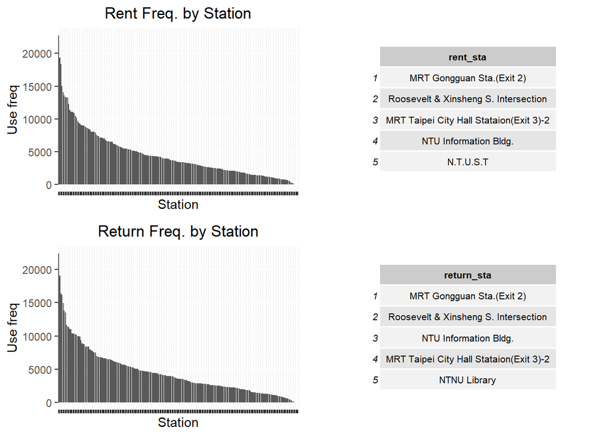

```r
# Rent station
a = data %>% group_by(rent_sta) %>% count() %>% ungroup()
a = a[order(a$n, decreasing = TRUE),]
fig1 = ggplot(data, aes(fct_infreq(rent_sta))) +
  geom_bar() +
  xlab("Station") +
  ylab("Use freq") +
  ggtitle("Rent Freq. by Station") +
  theme(axis.text.x = element_blank(),
        plot.title = element_text(hjust = 0.5))
# Return station
b = data %>% group_by(return_sta) %>% count() %>% ungroup()
b = b[order(b$n, decreasing = TRUE),]
fig2 = ggplot(data, aes(fct_infreq(return_sta))) +
  geom_bar() +
  xlab("Station") +
  ylab("Use freq") +
  ggtitle("Return Freq. by Station") +
  theme(axis.text.x = element_blank(),
        plot.title = element_text(hjust = 0.5))


# ref: https://cran.r-project.org/web/packages/egg/vignettes/Ecosystem.html
grid.arrange(fig1,
             tableGrob(a[1:5,1],theme = ttheme_default(base_size = 8)),
             fig2,
             tableGrob(b[1:5,1],theme = ttheme_default(base_size = 8))
             )
```

Import processed data

```r
options(stringsAsFactors = FALSE)
file_path = "NTU Information Bldg..csv"
data = read.csv(file_path)
```

## 0.1 Hoouly comparison(by station)

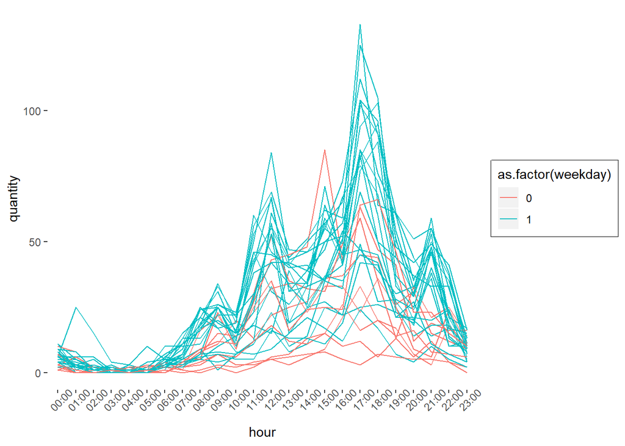

```r
data$day = data$index %>% substring(1, 10) %>% as.factor()
data$hour = data$index %>% substring(12,16)
data$DoW = weekdays(as.Date(data$day))
data$weekday = ifelse(isWeekday(as.Date(data$day)),1,0) %>% as.integer
data %>% ggplot() +
  geom_line(aes(x=hour, y = quantity, group = day, color = as.factor(weekday))) +
  theme(axis.text.x = element_text(angle = 45)) +
  theme(
    panel.background = element_rect(fill = "transparent") # bg of the panel
    , plot.background = element_rect(fill = "transparent", color = NA) # bg of the plot
    , panel.grid.major = element_blank() # get rid of major grid
    #, panel.grid.minor = element_blank() # get rid of minor grid
    #, legend.background = element_rect(fill = "transparent") # get rid of legend bg
    , legend.box.background = element_rect(fill = "transparent") # get rid of legend panel bg
  )
```

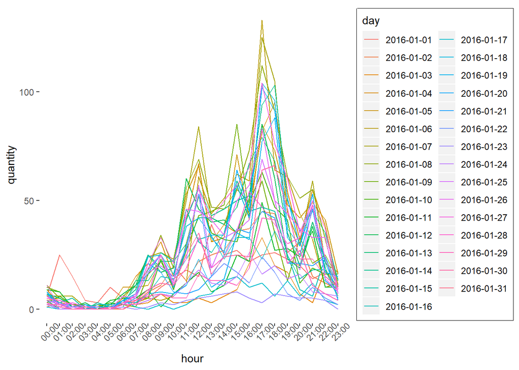

```r
data %>% ggplot() +
  geom_line(aes(x=hour, y = quantity, group = day, color = day)) +
  theme(axis.text.x = element_text(angle = 45)) +
  theme(
    panel.background = element_rect(fill = "transparent") # bg of the panel
    , plot.background = element_rect(fill = "transparent", color = NA) # bg of the plot
    , panel.grid.major = element_blank() # get rid of major grid
    #, panel.grid.minor = element_blank() # get rid of minor grid
    #, legend.background = element_rect(fill = "transparent") # get rid of legend bg
    , legend.box.background = element_rect(fill = "transparent") # get rid of legend panel bg
  )
```

##Weekly comparison(by station)

[figure not shown]

```r
data$WofM = c(rep(0,2*24), rep(1,7*24), rep(2,7*24), rep(3,7*24),rep(4,7*24),rep(5,1))
wk1 = data %>% filter(WofM==1)
wk2 = data %>% filter(WofM==2)
wk3 = data %>% filter(WofM==3)
wk4 = data %>% filter(WofM==4)
ggplot() +
    geom_line(aes(x=seq(1:168), y = wk1$quantity,color = 'wk1')) +
    geom_line(aes(x=seq(1:168), y = wk2$quantity,color = "wk2")) +
    geom_line(aes(x=seq(1:168), y = wk3$quantity,color = "wk3")) +
    geom_line(aes(x=seq(1:168), y = wk4$quantity,color = "wk4")) +
    scale_color_manual(values = c(
    'wk1' = 'dodgerblue',
    'wk2' = 'blue',
    'wk3' = 'darkblue',
    'wk4' = 'black')) +
    labs(color = 'Weekly Demand')+
    ylab("Demand") +
    xlab("MRT Taipei City Hall Stataion")
```

Train, Test split

```r
# train data: 2016/01/01 - 2016/01/23
train = data[1:(24*23),]

# test data: 2016/01/24 - 2016/01/30
test = data[(24*23+1):721,]
```

# 1 HMM Models

##Model_1: HMM w/o weekday

```r
hmm_model = "
functions {
  vector normalize(vector x) {
    return x / sum(x);
  }
}
data {
  int<lower=1> T; // 期數
  int<lower=1> K; // state數
  int y[T];       // observation
}

parameters {
  // Discrete state model
  simplex[K] pi1;  // initial state prob
  simplex[K] A[K]; // transition matrix
  // Poisson observation model
  ordered[K] lambdas;
}

transformed parameters {
  vector[K] logalpha[T];
  { // Forward algorithm log p(z_t = j | y_{1:t})
    real accumulator[K];
    logalpha[1] = log(pi1) + poisson_lpmf(y[1] | lambdas);
    for (t in 2:T) {
      for (j in 1:K) { // j = current (t)
      for (i in 1:K) { // i = previous (t-1)
      // Murphy (2012) p. 609 eq. 17.48
      // belief state      + transition prob + local evidence at t
      accumulator[i] = logalpha[t-1, i] + log(A[i, j]) + poisson_lpmf(y[t] | lambdas[j]);
      }
      logalpha[t, j] = log_sum_exp(accumulator);
      }
    }
  } // Forward
}

model {
  target += log_sum_exp(logalpha[T]); // Note: update based only on last logalpha
}

generated quantities {
  vector[K] alpha[T];

  vector[K] logbeta[T];
  vector[K] loggamma[T];

  vector[K] beta[T];
  vector[K] gamma[T];

  int<lower=1, upper=K> zstar[T];
  real logp_zstar;

  { // Forward algortihm
    for (t in 1:T)
      alpha[t] = softmax(logalpha[t]);
  } // Forward

  { // Backward algorithm log p(y_{t+1:T} | z_t = j)
    real accumulator[K];

    for (j in 1:K)
      logbeta[T, j] = 1;

    for (tforward in 0:(T-2)) {
      int t;
      t = T - tforward;

      for (j in 1:K) {    // j = previous (t-1)
      for (i in 1:K) {  // i = next (t)
      // Murphy (2012) Eq. 17.58
      // backwards t    + transition prob + local evidence at t
      accumulator[i] = logbeta[t, i] + log(A[j, i]) + poisson_lpmf(y[t] | lambdas[i]);
      }
      logbeta[t-1, j] = log_sum_exp(accumulator);
      }
    }

    for (t in 1:T)
      beta[t] = softmax(logbeta[t]);
  } // Backward

  { // forward-backward algorithm log p(z_t = j | y_{1:T})
    for(t in 1:T) {
      loggamma[t] = alpha[t] .* beta[t];
    }

    for(t in 1:T)
      gamma[t] = normalize(loggamma[t]);
  } // forward-backward



  { // Viterbi algorithm
    int bpointer[T, K]; // backpointer to the most likely previous state on the most probable path
    real delta[T, K];   // max prob for the sequence up to t
    // that ends with an emission from state k

    for (j in 1:K)
      delta[1, K] = poisson_lpmf(y[1] | lambdas[j]);

    for (t in 2:T) {
      for (j in 1:K) { // j = current (t)
      delta[t, j] = negative_infinity();
      for (i in 1:K) { // i = previous (t-1)
      real logp;
      logp = delta[t-1, i] + log(A[i, j]) + poisson_lpmf(y[t] | lambdas[j]);
      if (logp > delta[t, j]) {
        bpointer[t, j] = i;
        delta[t, j] = logp;
      }
      }
      }
    }

    logp_zstar = max(delta[T]);

    for (j in 1:K)
      if (delta[T, j] == logp_zstar)
        zstar[T] = j;

    for (t in 1:(T - 1)) {
      zstar[T - t] = bpointer[T - t + 1, zstar[T - t + 1]];
    }
  }
}"
#stan_model(model_code = hmm_model)
```

##Model_2: HMM with regression on lambda (weekday)

```r
hmm_model_2 = "
functions {
  vector normalize(vector x) {
    return x / sum(x);
  }
}
data {
  int<lower=1> T; // 期數
  int<lower=1> K; // state數
  int y[T];       // observation
  int w[T];       // weekday
  //vector<lower=0>[K] alpha;  // transit prior
}

parameters {
  // Discrete state model
  simplex[K] pi1;  // initial state prob
  simplex[K] A[K]; // transition matrix
  // Poisson observation model
  // Assumed lambda = a + bp
  // vector[K] lambda;
  vector<lower=0,upper=70>[K] a;
  vector<lower=0,upper=10>[K] bp;
}

transformed parameters {
  vector[K] logalpha[T];

  { // Forward algorithm log p(z_t = j | y_{1:t})
    real accumulator[K];
    logalpha[1] = log(pi1) + poisson_lpmf(y[1] | a + bp*w[1]);
    for (t in 2:T) {
      for (j in 1:K) { // j = current (t)
      for (i in 1:K) { // i = previous (t-1)
      // Murphy (2012) p. 609 eq. 17.48
      // belief state      + transition prob + local evidence at t
      accumulator[i] = logalpha[t-1, i] + log(A[i, j]) + poisson_lpmf(y[t] | a[j] + bp[j] * w[t]);
      }
      logalpha[t, j] = log_sum_exp(accumulator);
      }
    }
  } // Forward
}

model {
  //a ~ lognormal(mu, sigma)
  a[1] ~ lognormal(3,1);
  a[2] ~ lognormal(2,1);
  a[3] ~ lognormal(1,1);

  //b ~ normal(mu, sigma)
  bp[1] ~ lognormal(1,1);
  bp[2] ~ lognormal(1,1);
  bp[3] ~ lognormal(1,1);

  for (k in 1:K)
    A[k] ~ dirichlet(rep_vector(1, K));

  target += log_sum_exp(logalpha[T]); // Note: update based only on last logalpha
}

generated quantities {
  vector[K] alpha[T];

  vector[K] logbeta[T];
  vector[K] loggamma[T];

  vector[K] beta[T];
  vector[K] gamma[T];

  int<lower=1, upper=K> zstar[T];
  real logp_zstar;

  { // Forward algortihm
    for (t in 1:T)
      alpha[t] = softmax(logalpha[t]);
  } // Forward

  { // Backward algorithm log p(y_{t+1:T} | z_t = j)
    real accumulator[K];

    for (j in 1:K)
      logbeta[T, j] = 1;

    for (tforward in 0:(T-2)) {
      int t;
      t = T - tforward;

      for (j in 1:K) {    // j = previous (t-1)
      for (i in 1:K) {  // i = next (t)
      // Murphy (2012) Eq. 17.58
      // backwards t    + transition prob + local evidence at t
      accumulator[i] = logbeta[t, i] + log(A[j, i]) + poisson_lpmf(y[t] | a[i] + bp[i] * w[t]);
      }
      logbeta[t-1, j] = log_sum_exp(accumulator);
      }
    }

    for (t in 1:T)
      beta[t] = softmax(logbeta[t]);
  } // Backward

  { // forward-backward algorithm log p(z_t = j | y_{1:T})
    for(t in 1:T) {
      loggamma[t] = alpha[t] .* beta[t];
    }

    for(t in 1:T)
      gamma[t] = normalize(loggamma[t]);
  } // forward-backward



  { // Viterbi algorithm
    int bpointer[T, K]; // backpointer to the most likely previous state on the most probable path
    real delta[T, K];   // max prob for the sequence up to t
    // that ends with an emission from state k

    for (j in 1:K)
      delta[1, K] = poisson_lpmf(y[1] | a[j] + bp[j] * w[1]);

    for (t in 2:T) {
      for (j in 1:K) { // j = current (t)
      delta[t, j] = negative_infinity();
      for (i in 1:K) { // i = previous (t-1)
      real logp;
      logp = delta[t-1, i] + log(A[i, j]) + poisson_lpmf(y[t] | a[j] + bp[j] * w[t]);
      if (logp > delta[t, j]) {
        bpointer[t, j] = i;
        delta[t, j] = logp;
      }
      }
      }
    }

    logp_zstar = max(delta[T]);

    for (j in 1:K)
      if (delta[T, j] == logp_zstar)
        zstar[T] = j;

    for (t in 1:(T - 1)) {
      zstar[T - t] = bpointer[T - t + 1, zstar[T - t + 1]];
    }
  }
}"
#stan_model(model_code = hmm_model_2)
```

# 2 Method 1: Naive prediction

## 2.1 Model 1

Model 1 fitting

```r
hmm_init <- function(K, y) { # K: number of stages, y: y_train
  clasif <- kmeans(y, K)
  init.mu <- by(y, clasif$cluster, mean)
  init.sigma <- by(y, clasif$cluster, sd)
  init.order <- order(init.mu)
  list(
    mu = init.mu[init.order], sigma = init.sigma[init.order]
  ) }

hmm_VI_fit = function(K,y){ # K: number of stages, y: y_train
  rstan_options(auto_write = TRUE)
  options(mc.cores = parallel::detectCores())

  stan.model = stan_model(model_code = hmm_model)
  stan.data = list(
    T = length(y),
    K = K,
    y=y)
  vb(stan.model,
     data = stan.data,
     iter = 20000,
     init = function(){hmm_init(K,y)}
  )
}
```

Model 1 back_testing

```r
fit1.1 = hmm_VI_fit(3, data$quantity)
post1.1 = as.data.frame(fit1.1)
post1.1 = post1.1 %>% select(-contains("log")) %>% select(-contains("alpha")) %>% select(-contains("beta")) %>% select(-contains("gamma"))

post_pred = data_frame(index = seq(1:721))
```

```r
for(i in 1:nrow(post1.1)){
  lambda_lst = post1.1[i,13:15] %>% t() %>% as.vector()
  z_lst = post1.1[i,17:ncol(post1.1)-1] %>% t() %>% as.vector()
  mylist = c()
  for(j in 1:length(z_lst)){
    mylist = append(mylist,rpois(1,lambda_lst[z_lst[j]]))
  }
  post_pred = post_pred %>% cbind(.,mylist)
}

post_pred = post_pred[,2:ncol(post_pred)]

a = post_pred %>% apply(1,PI)

data$pred = post_pred %>% apply(1,mean)
data$l_PI = a[1,]
data$h_PI = a[2,]


fig1.1 = data %>%
  ggplot() +
  geom_point(aes(x=seq(1:721), y=quantity),color = 'dodgerblue') +
  geom_ribbon(aes(x=seq(1:721),
                  ymin = l_PI,
                  ymax = h_PI),
              alpha = 0.7) +
  geom_line(aes(x=seq(1:721), y=pred))+
  ggtitle("Model1 backtest")
```

Method 1: Prediction using transition matrix and state at last period of training data

```r
fit1.2 = hmm_VI_fit(3, train$quantity)
```

```r
post1.2 = as.data.frame(fit1.2)
post1.2 = post1.2 %>% select(-contains("log")) %>% select(-contains("alpha")) %>% select(-contains("beta")) %>% select(-contains("gamma"))

# prediction
hmm_predict_1 = function(data, T, K){
  # parameters
  A = matrix(data[4:(3+K^2)], nrow = K)
  lambda = as_vector(data[13:15])
  Z = unlist(data[567])

  # hidden path
  z = vector("numeric", T+1)
  z[1] = Z
  for (t in 2:(T+1)){
    z[t] = sample(1:K, size = 1, prob = A[z[t - 1], ])
  }

  # prediction
  y = vector("numeric", T)
  for (t in 1:T){
    y[t] = rpois(1, lambda[z[t+1]])
  }
  list(y = y, z = z[2:length(z)])
}

pred_1 =  post1.2 %>%
    apply(., MARGIN=1, FUN=hmm_predict_1, T=169, K=3) %>%
    lapply(., function (x) x[c('y')]) %>%
    unlist() %>%
    matrix(., nrow = 169) %>%
    apply(., MARGIN = 1, mean)
PI_1 =  post1.2 %>%
    apply(., MARGIN=1, FUN=hmm_predict_1, T=169, K=3) %>%
    lapply(., function (x) x[c('y')]) %>%
    unlist() %>%
    matrix(., nrow = 169) %>%
    apply(., MARGIN = 1, PI)

test$pred = pred_1
test$l_PI = PI_1[1,]
test$h_PI = PI_1[2,]
fig1.2 = test %>% ggplot() +
  geom_ribbon(aes(x=seq(553,721),
                  ymin=l_PI,
                  ymax=h_PI),alpha=0.7)+
  geom_point(aes(x=seq(553,721), y=quantity),color = 'dodgerblue') +
  geom_line(aes(x=seq(553,721),y=pred)) +
  ggtitle("Model1 + Method1")
```

## 2.2 Model 2 Back_testing and Naive prediction

Model 2 fitting

```r
hmm_VI_fit_2 = function(K,y,w){ # K: number of stages, y: y_train
  rstan_options(auto_write = TRUE)
  options(mc.cores = parallel::detectCores())

  stan.model = stan_model(model_code = hmm_model_2)
  stan.data = list(
    T = length(y),
    K = K,
    y=y,
    w=w)
  vb(stan.model,
     data = stan.data,
     iter = 20000,
     init = function(){hmm_init(K,y)}
  )
}
```

Model 2 back_testing

```r
fit_2 = hmm_VI_fit_2(3, data$quantity, as.integer(data$weekday))
```

```r
post_2 = as.data.frame(fit_2)
post_2 = post_2 %>% select(-contains("log")) %>% select(-contains("alpha")) %>% select(-contains("beta")) %>% select(-contains("gamma"))

post_2_pred = data_frame(index = seq(1:721),
                         weekday = as.integer(data$weekday))
for(i in 1:nrow(post_2)){
  z_lst = post_2[i,] %>%
    select(contains("zstar")) %>%
    t() %>% as.vector()
  mylist = c()
  for(j in 1:length(z_lst)){
    lambda_lst = post_2[j,13:15] + post_2[j,16:18] * post_2_pred[[j,2]] %>% t() %>% as.vector()
    mylist = append(mylist,rpois(1,lambda_lst[[z_lst[j]]]))
  }
  post_2_pred = post_2_pred %>% cbind(.,mylist)
}

post_2_pred = post_2_pred[,3:ncol(post_2_pred)]
a = post_2_pred %>% apply(1,PI)
data$pred_2 = post_2_pred %>% apply(1,mean)
data$l_PI_2 = a[1,]
data$h_PI_2 = a[2,]


fig2.1 = data %>%
  ggplot() +
  geom_ribbon(aes(x=seq(1:721),
                  ymin = l_PI_2,
                  ymax = h_PI_2),
              alpha = 0.7) +
  geom_point(aes(x=seq(1:721), y=quantity),color = 'dodgerblue') +
  geom_line(aes(x=seq(1:721), y=pred_2))+
  ggtitle("Model2 Backtest")
```

Method 1: Prediction using transition matrix and state at last period of training data

```r
fit2.2 = hmm_VI_fit_2(3, train$quantity, train$weekday)
post2.2 = as.data.frame(fit2.2)
post2.2 = post2.2 %>% select(-contains("log")) %>% select(-contains("alpha")) %>% select(-contains("beta")) %>% select(-contains("gamma"))
colnames(post2.2)
```

```
##   [1] "pi1[1]"     "pi1[2]"     "pi1[3]"     "A[1,1]"     "A[2,1]"
##   [6] "A[3,1]"     "A[1,2]"     "A[2,2]"     "A[3,2]"     "A[1,3]"
##  [11] "A[2,3]"     "A[3,3]"     "a[1]"       "a[2]"       "a[3]"
##  [16] "bp[1]"      "bp[2]"      "bp[3]"      "zstar[1]"   "zstar[2]"
##  [21] "zstar[3]"   "zstar[4]"   "zstar[5]"   "zstar[6]"   "zstar[7]"
##  [26] "zstar[8]"   "zstar[9]"   "zstar[10]"  "zstar[11]"  "zstar[12]"
##  [31] "zstar[13]"  "zstar[14]"  "zstar[15]"  "zstar[16]"  "zstar[17]"
##  [36] "zstar[18]"  "zstar[19]"  "zstar[20]"  "zstar[21]"  "zstar[22]"
##  [41] "zstar[23]"  "zstar[24]"  "zstar[25]"  "zstar[26]"  "zstar[27]"
##  [46] "zstar[28]"  "zstar[29]"  "zstar[30]"  "zstar[31]"  "zstar[32]"
##  [51] "zstar[33]"  "zstar[34]"  "zstar[35]"  "zstar[36]"  "zstar[37]"
##  [56] "zstar[38]"  "zstar[39]"  "zstar[40]"  "zstar[41]"  "zstar[42]"
##  [61] "zstar[43]"  "zstar[44]"  "zstar[45]"  "zstar[46]"  "zstar[47]"
##  [66] "zstar[48]"  "zstar[49]"  "zstar[50]"  "zstar[51]"  "zstar[52]"
##  [71] "zstar[53]"  "zstar[54]"  "zstar[55]"  "zstar[56]"  "zstar[57]"
```

[output cut: 100 more lines]

```r
# prediction
hmm_predict_2 = function(data, T, K, weekday_lst){
  # parameters
  A = matrix(data[4:(3+K^2)], nrow = K)
  Z = data[570] %>% unlist()
  a = data[13:15] %>% unlist()
  bp = data[16:18] %>% unlist()
  # hidden path
  z = vector("numeric", T+1)
  z[1] = Z
  for (t in 2:(T+1)){
    z[t] = sample(1:K, size = 1, prob = A[z[t - 1], ])
  }
  y = vector("numeric", T)
  for (t in 1:T){
    y[t] = rpois(1, lambda = a[z[t+1]] + bp[z[t+1]]*weekday_lst[t])
  }
  list(y = y, z = z[2:length(z)])
}

pred_2 = post2.2 %>%
    apply(., MARGIN=1, FUN=hmm_predict_2, T=169, K=3, test$weekday) %>%
    lapply(., function (x) x[c('y')]) %>%
    unlist() %>%
    matrix(., nrow = 169) %>%
    apply(., MARGIN = 1, mean)

PI_2 = post2.2 %>%
    apply(., MARGIN=1, FUN=hmm_predict_2, T=169, K=3, test$weekday) %>%
    lapply(., function (x) x[c('y')]) %>%
    unlist() %>%
    matrix(, nrow = 169) %>%
    apply(., MARGIN = 1, PI)

test$pred_2 = pred_2
test$l_PI_2 = PI_2[1,]
test$h_PI_2 = PI_2[2,]

fig2.2 = test %>% ggplot() +
   geom_ribbon(aes(x=seq(553,721),
                  ymin = l_PI_2,
                  ymax = h_PI_2),alpha=0.7) +
  geom_point(aes(x=seq(553,721), y=quantity),color = 'dodgerblue') +
  geom_line(aes(x=seq(553,721),y=pred_2))+
  ggtitle("Model2 + Method1")
```

## 2.3 Back_testing Comparison

The results show that both 2 models are able to capture the historical states.

```r
# RMSE comparison
cat("The RMSE of model_1 is ", RMSE(data$pred, data$quantity))
```

```
## The RMSE of model_1 is  10.35893
```

```r
cat("The RMSE of model_2 is ", RMSE(data$pred_2, data$quantity))
```

```
## The RMSE of model_2 is  10.25598
```

```r
fit_logalpha = as.data.frame(fit1.1) %>% select(contains('logalpha'))
fit_logalpha = fit_logalpha %>%
  select(`logalpha[721,1]`,`logalpha[721,2]`,`logalpha[721,3]`)

fit_2_logalpha = as.data.frame(fit_2) %>% select(contains('logalpha'))
fit_2_logalpha = fit_2_logalpha %>%
  select(`logalpha[721,1]`,`logalpha[721,2]`,`logalpha[721,3]`)

log_list <- list(fit_logalpha, fit_2_logalpha)
test <- lapply(log_list, as.matrix)
waic_list <- list()
loo_list <- list()
for(i in 1:2) {
waic_list[[i]] <- waic(test[[i]], r_eff = rel_n_eff_list[[i]], cores = 4)
loo_list[[i]] <- loo(test[[i]], cores = 4)
}
names(waic_list) <- c('fit1', 'fit2')
print(waic_list)
```

```
## $fit1
##
## Computed from 1000 by 3 log-likelihood matrix
##
##           Estimate   SE
## elpd_waic  -9405.9 34.7
## p_waic        37.1  0.8
## waic       18811.9 69.3
```

```
##
## $fit2
##
## Computed from 1000 by 3 log-likelihood matrix
##
##           Estimate   SE
## elpd_waic  -9341.7 28.3
## p_waic        65.3  0.3
## waic       18683.3 56.6
```

```r
print(loo_list)
```

```
## [[1]]
##
## Computed from 1000 by 3 log-likelihood matrix
##
##          Estimate   SE
## elpd_loo  -9406.4 34.9
## p_loo        37.6  0.7
## looic     18812.8 69.9
## ------
## Monte Carlo SE of elpd_loo is NA.
##
## Pareto k diagnostic values:
##                          Count Pct.    Min. n_eff
## (-Inf, 0.5]   (good)     0       0.0%  <NA>
##  (0.5, 0.7]   (ok)       0       0.0%  <NA>
##    (0.7, 1]   (bad)      0       0.0%  <NA>
##    (1, Inf)   (very bad) 3     100.0%  1
## See help('pareto-k-diagnostic') for details.
##
## [[2]]
##
## Computed from 1000 by 3 log-likelihood matrix
##
##          Estimate   SE
## elpd_loo  -9350.0 28.7
## p_loo        73.7  0.7
## looic     18700.1 57.3
## ------
## Monte Carlo SE of elpd_loo is NA.
##
## Pareto k diagnostic values:
##                          Count Pct.    Min. n_eff
## (-Inf, 0.5]   (good)     0       0.0%  <NA>
##  (0.5, 0.7]   (ok)       0       0.0%  <NA>
##    (0.7, 1]   (bad)      0       0.0%  <NA>
##    (1, Inf)   (very bad) 3     100.0%  1
## See help('pareto-k-diagnostic') for details.
```

## 2.4 Train/Test Comparison

We can tell that both the 2 models have very poor prediction on t+1~t+169 since the predicted state is locked at t.

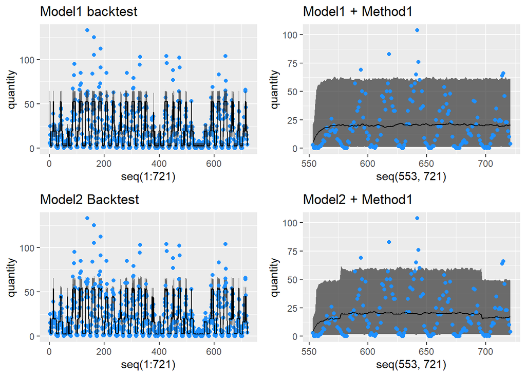

```r
# graph comparison
grid.arrange(fig1.1, fig1.2, fig2.1, fig2.2, nrow = 2)
```

# 3 Revised Prediction Method

**Assumption: Same day of the week should be in similar state** Predict the state based on trained state

```r
# Extract most likely path from posterior
zlst1.2 = post1.2 %>% select(contains('zstar')) %>% apply(FUN=MODE, MARGIN = 2) %>% unlist()
zlst2.2 = post2.2 %>% select(contains('zstar')) %>% apply(FUN=MODE, MARGIN = 2) %>% unlist()
train$z_1 = zlst1.2
train$z_2 = zlst2.2
train$hourly = rep(seq(1:24),23) - 1
train$date = train$index %>% str_sub(1,11)
train$dayofweek = as.POSIXlt(train$index)$wday + 1
```

## 3.1 Method 2: Predict the state in each hour of Monday ~ Sunday using MODE of past 3 weeks

```r
pred_1_z = c()
for (i in seq(1:7)){
  temp = train %>%
    filter(dayofweek == i) %>%
    select(z_1,hourly,date) %>%
    spread(, key=date, value=z_1) %>%
    apply(MARGIN = 1, FUN = MODE)
  if (i == 1) pred_1_z = temp
  else pred_1_z = append(pred_1_z,temp)
}

pred_2_z = c()
for (i in seq(1:7)){
  temp = train %>%
    filter(dayofweek == i) %>%
    select(z_2,hourly,date) %>%
    spread(, key=date, value=z_2) %>%
    apply(MARGIN = 1, FUN = MODE)
  if (i == 1) pred_2_z = temp
  else pred_2_z = append(pred_2_z,temp)
}

test_2 = data[(24*23+1):720,]
test_2$pred_1_z = pred_1_z
test_2$pred_2_z = pred_2_z
```

Make prediction based on predicted states (MODE)

```r
pred_1.2 = function(z){
  a = rpois(1000, post1.2[,12+z])
  return(a)
}

test_2$pred_1_mean = test_2$pred_1_z %>%
  mapply(FUN=pred_1.2) %>%
  apply(FUN=mean,MARGIN = 2)

test_2$pred_1_lPI = test_2$pred_1_z %>%
  mapply(FUN=pred_1.2) %>%
  apply(FUN=PI,MARGIN = 2) %>% .[1,]

test_2$pred_1_hPI = test_2$pred_1_z %>%
  mapply(FUN=pred_1.2) %>%
  apply(FUN=PI,MARGIN = 2) %>% .[2,]


pred_2.2 = function(z,w){
  a = rpois(1000, post2.2[,12+z]+post2.2[,15+z]*w)
  return(a)
}

for (i in c(1:nrow(test_2))){
  test_2$pred_2_mean[i] =
    pred_2.2(test_2$pred_2_z[i], test_2$weekday[i]) %>% mean
  test_2$pred_2_hPI[i] =
    pred_2.2(test_2$pred_2_z[i], test_2$weekday[i]) %>%
    PI %>% .[2]
  test_2$pred_2_lPI[i] =
    pred_2.2(test_2$pred_2_z[i], test_2$weekday[i]) %>%
    PI %>% .[1]
}
```

Plot the prediction result

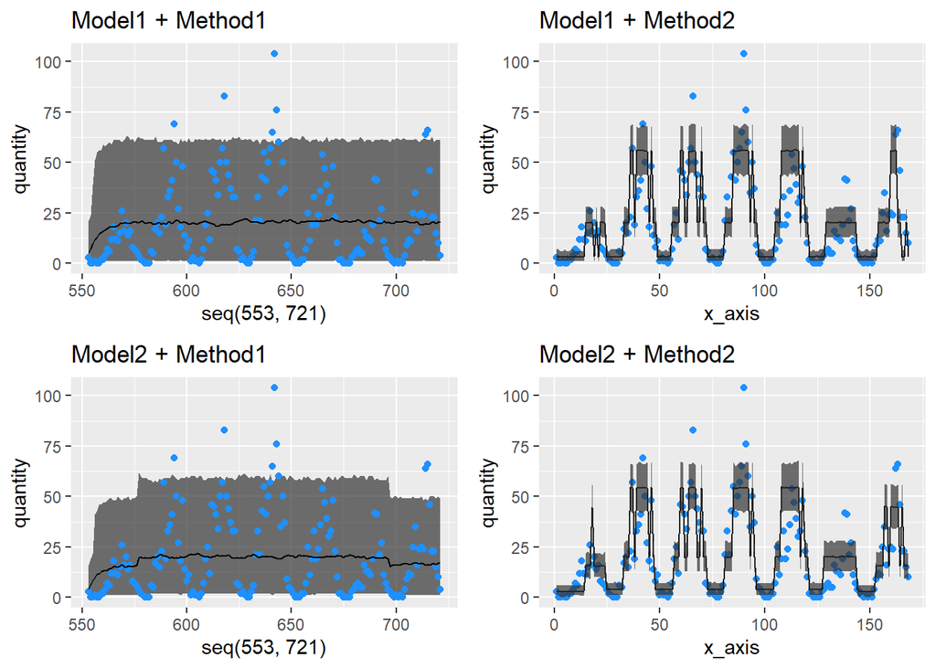

```r
test_2$x_axis = seq(1:nrow(test_2))
fig1.3 = test_2 %>% ggplot() +
  geom_point(aes(x=x_axis, y=quantity), color = 'dodgerblue') +
  geom_line(aes(x=x_axis, y=pred_1_mean)) +
  geom_ribbon(aes(x=x_axis,
                  ymin = pred_1_lPI,
                  ymax = pred_1_hPI),
              alpha = 0.7) +
  ggtitle("Model1 + Method2")

fig2.3 = test_2 %>% ggplot() +
  geom_point(aes(x=x_axis, y=quantity), color = 'dodgerblue') +
  geom_line(aes(x=x_axis, y=pred_2_mean)) +
  geom_ribbon(aes(x=x_axis,
                  ymin = pred_2_lPI,
                  ymax = pred_2_hPI),
              alpha = 0.7) +
  ggtitle("Model2 + Method2")
grid.arrange(fig1.2, fig1.3, fig2.2, fig2.3, nrow=2)
```

```r
cat("The RMSE of model_1 + method_2 is", RMSE(test_2$pred_1_mean, test_2$quantity),"\n")
```

```
## The RMSE of model_1 + method_2 is 12.95023
```

```r
cat("The RMSE of model_2 + method_2 is", RMSE(test_2$pred_2_mean, test_2$quantity))
```

```
## The RMSE of model_2 + method_2 is 12.3565
```

## 3.2 Method 3: Use all the states of the past 3 weeks

```r
train2 = train[(24*2+1):(24*23),] # only use full weeks from 1/3 ~ 1/23
for (i in (1:7)){
  temp = train2 %>%
    filter(dayofweek == i) %>%
    select(z_1,hourly,date) %>%
    spread(, key=date, value=z_1) %>%
    select(-hourly)
  names(temp)<-c("w1","w2","w3")
  if (i == 1) pred_3_z = temp
  else pred_3_z = rbind(pred_3_z,temp)
}

for (i in seq(1:7)){
  temp = train2 %>%
    filter(dayofweek == i) %>%
    select(z_2,hourly,date) %>%
    spread(, key=date, value=z_2) %>%
    select(-hourly)
  names(temp)<-c("w1","w2","w3")
  if (i == 1) pred_4_z = temp
  else pred_4_z = rbind(pred_4_z,temp)
}
```

Prediction using past 3 weeks and take average

```r
pred_3_z
```

| w1 | w2 | w3 |
| --- | --- | --- |
| 1 | 1 | 1 |
| 1 | 1 | 1 |
| 1 | 1 | 1 |
| 1 | 1 | 1 |
| 1 | 1 | 1 |
| 1 | 1 | 1 |
| 1 | 1 | 1 |
| 1 | 1 | 1 |
| 1 | 1 | 1 |
| 1 | 2 | 1 |

[output cut: 158 more lines]

```r
for (i in 1:nrow(pred_3_z)){
  pred_3_z$pred_mean[i] = 1/3 * mean(
    pred_1.2(pred_3_z$w1[i])+
    pred_1.2(pred_3_z$w2[i])+
    pred_1.2(pred_3_z$w3[i]))

  pred_3_z$pred_lPI[i] = 1/3 * PI(
    pred_1.2(pred_3_z$w1[i])+
    pred_1.2(pred_3_z$w2[i])+
    pred_1.2(pred_3_z$w3[i]))[1]

  pred_3_z$pred_hPI[i] =
    1/3 * PI(
    pred_1.2(pred_3_z$w1[i])+
    pred_1.2(pred_3_z$w2[i])+
    pred_1.2(pred_3_z$w3[i]))[2]
}

pred_4_z$weekday = test_2$weekday
for (i in c(1:nrow(pred_4_z))){
  pred_4_z$pred_mean[i] =
    1/3 * mean(
    pred_2.2(pred_4_z$w1[i], pred_4_z$weekday[i])+
    pred_2.2(pred_4_z$w2[i], pred_4_z$weekday[i])+
    pred_2.2(pred_4_z$w3[i], pred_4_z$weekday[i]))

  pred_4_z$pred_lPI[i] =
    1/3 * PI(
    pred_2.2(pred_4_z$w1[i], pred_4_z$weekday[i])+
    pred_2.2(pred_4_z$w2[i], pred_4_z$weekday[i])+
    pred_2.2(pred_4_z$w3[i], pred_4_z$weekday[i]))[1]

  pred_4_z$pred_hPI[i] =
    1/3 * PI(
    pred_2.2(pred_4_z$w1[i], pred_4_z$weekday[i])+
    pred_2.2(pred_4_z$w2[i], pred_4_z$weekday[i])+
    pred_2.2(pred_4_z$w3[i], pred_4_z$weekday[i]))[2]
}
```

Method 3 Prediction Comparison

```r
# RMSE Comparison
pred_3_z$quantity = test_2$quantity
pred_4_z$quantity = test_2$quantity
RMSE(pred_3_z$pred_mean, pred_3_z$quantity)
```

```
## [1] 11.96565
```

```r
RMSE(pred_4_z$pred_mean, pred_4_z$quantity)
```

```
## [1] 11.70952
```

```r
# Graphical Comparison
pred_3_z$x_axis = seq(1:168)
pred_4_z$x_axis = seq(1:168)

fig1.4 = pred_3_z %>% ggplot() +
  geom_point(aes(x=x_axis, y=quantity), color = 'dodgerblue') +
  geom_line(aes(x=x_axis, y=pred_mean)) +
  geom_ribbon(aes(x=x_axis,
                  ymin = pred_lPI,
                  ymax = pred_hPI),
              alpha = 0.7)+
  ggtitle("Model1 + Method3")

fig2.4 = pred_4_z %>% ggplot() +
  geom_point(aes(x=x_axis, y=quantity), color = 'dodgerblue') +
  geom_line(aes(x=x_axis, y=pred_mean)) +
  geom_ribbon(aes(x=x_axis,
                  ymin = pred_lPI,
                  ymax = pred_hPI),
              alpha = 0.7) +
  ggtitle("Model2 + Method3")
```

# 4 Compare all 3 methods

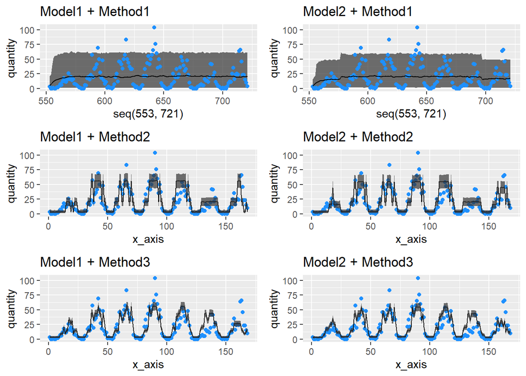

```r
grid.arrange(fig1.2, fig2.2, fig1.3, fig2.3, fig1.4, fig2.4, nrow=3)
```

```r
cat("The RMSE of model_1 + method_2 is",
    RMSE(test_2$pred_1_mean, test_2$quantity),"\n")
```

```
## The RMSE of model_1 + method_2 is 12.95023
```

```r
cat("The RMSE of model_2 + method_2 is",
    RMSE(test_2$pred_2_mean, test_2$quantity),"\n")
```

```
## The RMSE of model_2 + method_2 is 12.3565
```

```r
cat("The RMSE of model_1 + method_3 is",
    RMSE(pred_3_z$pred_mean, pred_3_z$quantity),"\n")
```

```
## The RMSE of model_1 + method_3 is 11.96565
```

```r
cat("The RMSE of model_2 + method_3 is",
    RMSE(pred_4_z$pred_mean, pred_4_z$quantity))
```

```
## The RMSE of model_2 + method_3 is 11.70952
```

# 5 Reference

ref_1: https://discourse.mc-stan.org/t/fitting-a-hidden-markov-model-with-hierarchical-emission-parameters/1404/3

ref_2: https://mc-stan.org/docs/2_18/stan-users-guide/hmms-section.html

ref_3: https://zenodo.org/record/1284341/files/main_pdf.pdf?download=1

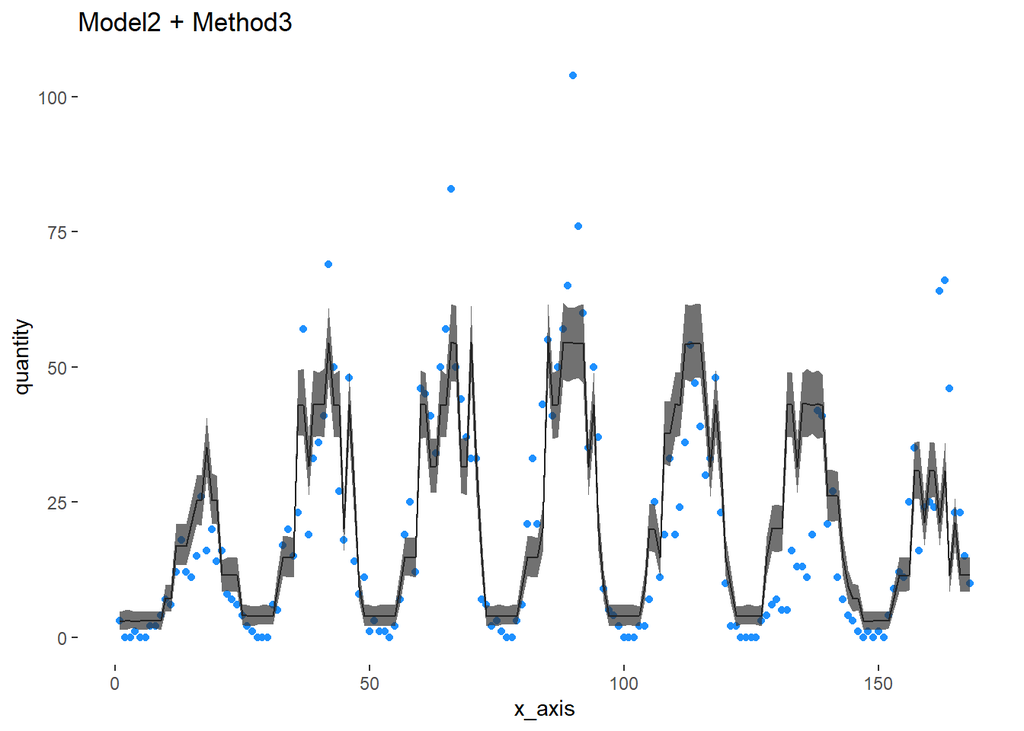

```r
fig2.4 +
  theme(
    panel.background = element_rect(fill = "transparent") # bg of the panel
    , plot.background = element_rect(fill = "transparent", color = NA) # bg of the plot
    , panel.grid.major = element_blank() # get rid of major grid
    #, panel.grid.minor = element_blank() # get rid of minor grid
    #, legend.background = element_rect(fill = "transparent") # get rid of legend bg
    , legend.box.background = element_rect(fill = "transparent") # get rid of legend panel bg
  )
```